# Capstone Project Milestone Report - London house prices

Jaymin Mistry

28 March 2017

### Problem

Property prices in London are already high, this is partly due to large demand and insufficient supply. I want to understand the factors that contribute to differences in house prices for similar type properties within the Greater London area with open source data (access to transport, facilities, schooling etc). I am curious whether there are factors that are not normally considered when searching for a property that affect values and what weighting they have relative to each other.

### Audience and decision output

This information will primarily be useful to anyone considering purchasing a property in London. It would also be useful for estate agents and the property listing websites in the UK (Zoopla, Rightmove and Onthemarket) to identify trends.

For house purchasers, this may highlight areas, which are underpriced and offer good value. Alternatively it may highlight areas, which have similar characteristics but are not regularly considered. For estate agents and property websites, it could provide a guide to understanding what people are actually looking for and therefore provide alternatives.

### What important fields and information does the data set have?

The Land registry dataset contains price paid, date of sale and the property type. It also includes whether it is a freehold or leasehold property and it indicates whether it is a new build property or not. This will only allow me to infer the age of properties built since 1995.

The Metropolitan crime dataset breaks down crime rates into major and minor categories and is split down into anonymised areas at LSOA (Lower Layer Super Output Area) level with a mean size of 1500 people.

There is a huge amount of data available for schooling across the Uk, including money spent the pupil, GCSE results (aged 16), school leaver destinations and A level results (age 18) and destination. I have decided to use GCSE results as a proxy for school quality. GCSE results are a broad indicator of A level performance and therefore overall school performance.

### Limitations i.e. what are some questions that you cannot answer with this data set?

The key difficulty I faced is that I am attempting to correlate geospatial data in R. Constructing geospatial models to calculate times is possible but difficult in R and a distraction from the problem I am attempting to solve. Using absolute distance from a central point is possible would mask regions, which are centrally located but poorly served by public transport and vice versa. There is a google maps distance matrix API, which can provide journey times via public transport. However it is limited to 2.5k queries a day.

2. I have not been able to acquire data on the number of rooms. I assess this is a major factor in house prices but I cannot get access to any dataset containing this information.
3. I have not found a data set containing ages of property (although this can be deduced for new build properties since 1995)
4. Crime data is anonymised to month and LSOA.
5. It is impossible to see whether children go to school across council boundaries or attend boarding school. I am therefore going to assume that the majority of children attend schools within their council area.

### A deeper dive into the data set:

The key data set is the prices paid for property from the Land Registry, which lists the majority of property sales since 1995.

```r
head(london16)
```

```
##   X Postcode Price.... Property.Type New Freehold.Leasehold     SAON
## 1 1    E47UN    210000             F   N                  L  FLAT 31
## 2 2   EN51QJ    337000             F   N                  L FLAT 504
## 3 3   NW34SW    475000             F   N                  L     <NA>
## 4 4  SE185LL     29000             O   N                  F     <NA>
## 5 5   TW27SA    775000             S   N                  F     <NA>
## 6 6   BR27JX    710000             S   N                  F     <NA>
##             Number           Road   Locality  Town.City
## 1 RIVERSIDECOURT+1 CHELWOOD CLOSE       <NA>     LONDON
## 2    COMERHOUSE+19   STATION ROAD NEW BARNET     BARNET
## 3               20  BEAUMONT WALK       <NA>     LONDON
## 4              110  SAMUEL STREET       <NA>     LONDON
## 5               71      COURT WAY       <NA> TWICKENHAM
## 6                7  STUART AVENUE       <NA>    BROMLEY
##               District Date.of.Transfer PPD.Category.Type
```

[output cut: 20 more lines]

The subset of the prices paid data extracted from the Land Registry, shows the postcode, price paid, type of property, whether it is a new build or not, further address information, sale date and a unique transaction ID. To this, I have added a address field in one box and categorised each property into a price bracket.

Early examination of the crime dataset suggested that the amount of crime in the City of London District is disproportionate to its population. This may be due to the large numbers of tourists and workers, who do not reside in the District but visit in the day.

### What kind of cleaning and wrangling did you need to do?

The Land Registry Dataset was downloaded complete with all transactions from 1995 to the present day, the file was 3.8Gb. This was split into 10 segments, imported and filtered in R to give ~ 3 million property transactions in London. From this I extracted all sales from 1 Jan 16 till present (13 months), which yielded ~115k sales. To minimise the number of queries I need, I have simplified it to unique postcodes, for which there are ~60k. I have used the google maps distance API via gmapsdistance package in R to calculate the journey time for each address. I sampled this dataset to collect a random portion, as I was limited to the number of queries I could make.

## Gmapsdistance API.

To calculate journey times and therefore assign a value to how accessible each address is, I used the Google maps distance matrix API to calculate the time a public transport journey would take from a postcode to a point in central London (in this case UCL: WC1 6BT). This score I am using a proxy for accessibility to transport. This is imperfect as many people do not work in the city centre, some drive to work and some people commute out of London, it provides the best numerical score without constructing my own spatial models.

There was a limit of 2500 requests per day, so I have randomly sampled 10,000 postcodes from the dataset to calculate times for. As postcodes cover a small geographical area, there is minimal time difference between the different addresses within each.

```r
temp <- gmapsdistance(set.api.key("xxx"),
                         origin = london2[1:500,1],
                         destination = "WC1E6BT",
                         mode = "transit",
                         dep_date = "2017-05-02",
                         dep_time = "09:00:00",
                         combinations = "all")
```

This produces 3 lists, which are then manipulated with a lapply function to produce a single dataframe.

```r
res <- data.frame(origin = london1[, 1],
                  desination = 'WC1E6BT',
                  do.call(data.frame, lapply(temp, function(x) x[, 2])))
```

The final output is a time in seconds to make a journey from the start postcode to WC1 6BT, using the best combination of walking and public transport.

### Any preliminary exploration you’ve performed and your initial findings.

Having examined the prices for London property sold since 1 Jan 16, I explored the type and value of properties sold in this period.

# histogram showing the different types of properties sold

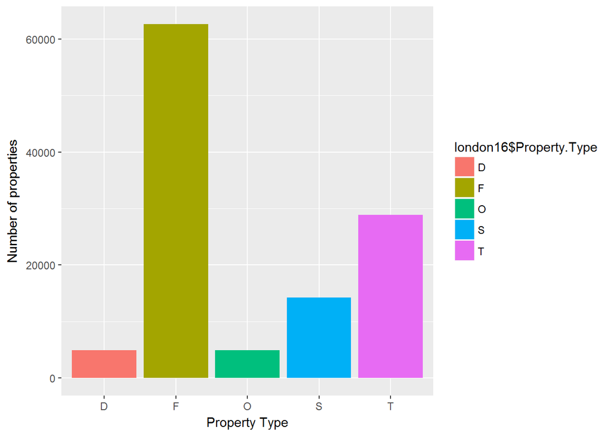

```r
ggplot(london16, aes(x = london16$Property.Type, fill = london16$Property.Type)) +
 geom_histogram(stat = "count") +
     xlab("Property Type") +
     ylab("Number of properties")
```

# graphs showing distibution of property sold for each price bracket

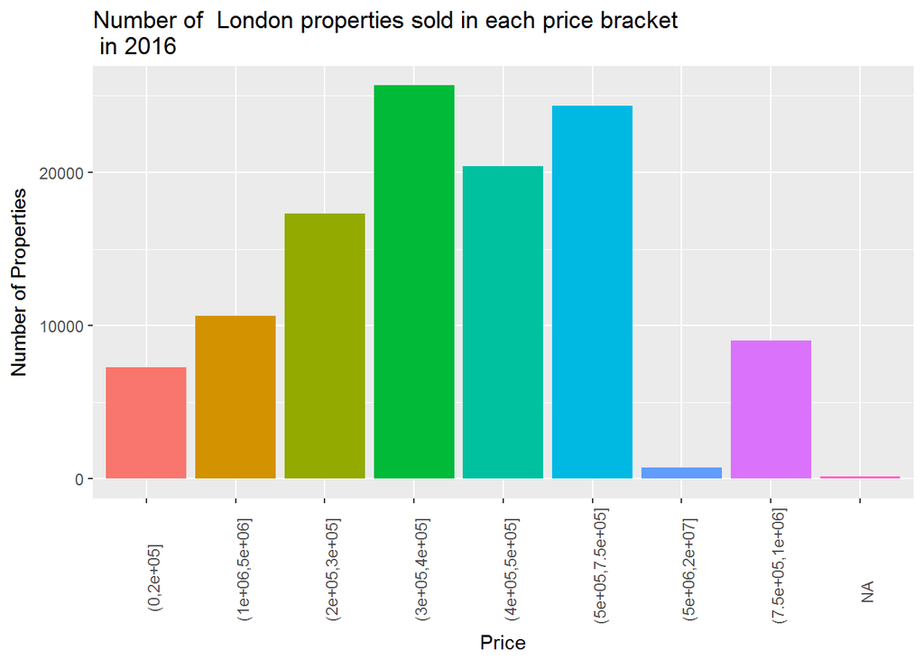

```r
 require(scales)
 ggplot(london16, aes(x = london16$pricebracket))+
     geom_histogram(stat="count",  aes(fill = london16$pricebracket)) +
     xlab("Price") +
     ylab("Number of Properties") +
     theme(axis.text.x = element_text(angle =90)) +
     theme(legend.position="none")+
     ggtitle("Number of  London properties sold in each price bracket \n in 2016")
```

As expected the majority of the properties sold are in the central value of 200-750k, with fewer cheap or expensive properties being sold.

# Sales by district

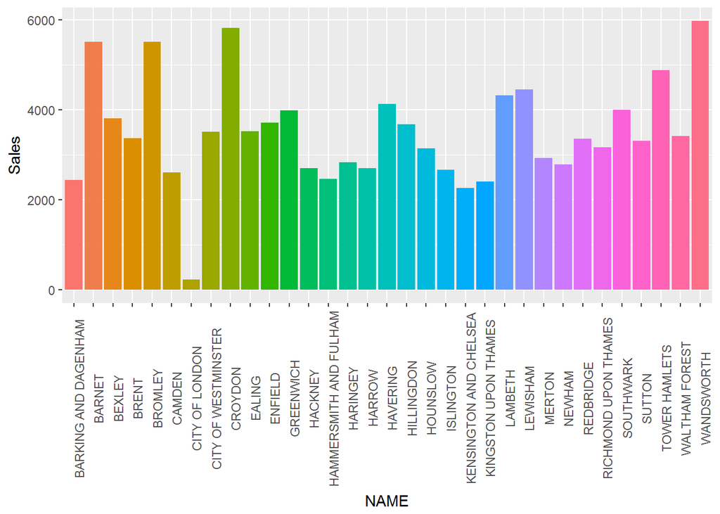

```r
ggplot(salesbydistrict, aes(x = NAME, y = Sales, fill = NAME)) +      geom_bar(stat = "identity") +
     theme(axis.text.x = element_text(angle = 90)) +
     theme(legend.position = "none")
```

As a key outlier, the City of London has significantly fewer sales, most likely due to its small size and population.

### Based on these findings, what approach are you going to take?

My intent is to construct a linear regression model analysing 1) public transport time to central london 2) crime rates 3) education.

I will do this using the Gmaps API to collect journey time to a single point in central London. Whilst I cannot examine individual pupils and account for proportions of students that move across District boundaries. I will use GCSE results as a proxy for the quality of education in each area. I will compare overall crime levels and crime per unit population to ascertain if this correlates with property price.

### Outputs

1. Explanation of the statistical model and data analysis in a Github repository.
2. A model relating some or all of the factors I have identified in this project, relative to house price.
3. A slide deck/paper articulating my findings to include:
- Factors that contribute to property values.
- Identification of under/overvalued properties/ areas.
- Potential R.Shiny interactive map/tool.